# ML_VII_Independent_Analysis_Part_2

2026-02-20

### Name: Tesfalem Tessema (ID: 11420026)

```r
knitr::opts_chunk$set(echo = TRUE)
library(tidyverse)
library(tidymodels)
library(sjPlot)
library(finalfit)
library(knitr)
library(mice)
library(naniar)
library(gtsummary)
library(mlbench)
library(kernlab)
library(vip)
library(rsample)
library(tune)
library(recipes)
library(yardstick)
library(parsnip)
library(glmnet)
library(themis)
library(microbenchmark)
library(reportRmd)
library(plotly)
library(dplyr)
library(psych)
library(parallel)
library(corrr)
library(performance)
library(utils)
library(see)
library(devtools)
library(tidyclust)
library(ClusterR)
library(klaR)
library(GGally)
library(ggplot2)
```

### Introduction

This project is designed to conduct complete data analysis using machine learning techniques. Building on the first part of the assignment, a complete analysis including data wrangling, handling missing data, and the application of machine learning methods.

### Objective

The main objective of this analysis is to apply machine learning techniques to classify children as non-immunized (Zero dose) based on various socio-demographic, knowledge, perception, and health service–related factors. The most influential features associated with immunization status of children are also identified, where appropriate.

### Data Description

For the analysis, a dataset derived from raw data collected in Ethiopia in 2022 is used. This data was collected as part of a baseline survey designed to assess childhood immunization coverage and its associated factors among selected host and refugee populations in one of the remote regions (Gambella Region) of Ethiopia. The survey was conducted following the World Health Organization’s (WHO’s) Vaccination Coverage Cluster Surveys Reference Manual. Accordingly, the data were collected in the sample of 3,200 children aged 12–23 months and their mothers or caretakers. It has a total of 84 variables (Subset of the dataset) that captured information on demographic characteristics, socioeconomic status, health‑care access, and knowledge, attitudes, and practices (KAP) related to childhood immunization are used for the present analysis. This dataset was selected due to its close similarity to the key components of Demographic and Health Survey (DHS) data, which are widely used in analyses of immunization coverage. After applying machine learning methods on this dataset, I am planning to apply the same approach to the 2024/2025 Ethiopian DHS data, which is expected to become available in the coming months.

### Data Analysis

*Part 1:* This section presented the data cleaning and exploration steps, which are already submitted as part of the ** Independent Analysis Part 1 Assignment**.

*Part 2:* This section present the application of three machine learning concepts (Logistic regression, Random forest, and Artificial Neural Network) to answer the research questions. The rationale and the detail of the procedures used for each of the machine learning methods are described in the respective sections below.

## Part 1:Data Wrangling and preprocessing including handling missing data

```r
# Loading the revised dataset

data1 <-read_csv("ML_Immunization_BL_data_20_Feb_26_2.csv")
```

[output not shown]

```r
# Checking for missing values
missing_table <- miss_var_summary(data1)
missing_table
```

```
## # A tibble: 84 × 3
##    variable                n_miss pct_miss
##    <chr>                    <int>    <num>
##  1 Dis_staff_not_friendly    2830     88.4
##  2 Dis_dverse_effect         2830     88.4
##  3 Dis_long_waiting          2830     88.4
##  4 Dis_service_close         2830     88.4
##  5 Dis_no_vaccine            2830     88.4
##  6 Dis_no_staff              2830     88.4
##  7 Who_Newborns              2099     65.6
##  8 Who_Sick                  2099     65.6
##  9 Who_Physically_handi_ca   2099     65.6
## 10 Received_vacc             1798     56.2
## # ℹ 74 more rows
```

We have 31 variables with missing values ranging from less than 1% to 88%. Although most of these missing values are due to the nature of the data where some questions were not applicable to all respondents, I have imputed the missing values for the purpose of this assignment using MICE.

```r
# Imputing missing values

mice_all <- mice(data1, method = "cart", m = 1, maxit = 1)
mice_all$method
```

```
##                             ID                      Sex_Child
##                             ""                             ""
##                      Age_Child                 Marital_status
##                             ""                         "cart"
##                     Age_mother           Mother_read_or_write
##                             ""                             ""
##                     Age_father           Father_read_or_write
##                             ""                             ""
##                        HH_size                 Child_under_18
##                             ""                             ""
##                  Child_under_5                      HH_income
##                             ""                             ""
##                      Residence               Time_to_imm_site
##                             ""                             ""
##                         ANC_Px                         No_ANC
##                             ""                         "cart"
##                    Place_birth                            PNC
##                             ""                             ""
##                         No_PNC                  When_to_immun
##                         "cart"                         "cart"
##                         HE_Imm           No_sessions_comp_imm
##                             ""                         "cart"
##                   Age_comp_imm                 Identify_Ds_Tb
##                         "cart"                             ""
##              Identify_Ds_polio          Identify_Ds_diptheria
##                             ""                             ""
##           Identify_Ds_purtusis            Identify_Ds_tetanus
##                             ""                             ""
##           Identify_Ds_measeles          Identify_Ds_pneumonia
##                             ""                             ""
##               Identify_Ds_Meng                Identify_Ds_HPB
##                             ""                             ""
##           Identify_Ds_diarreah       Some_children_should_not
##                             ""                             ""
##                   Who_Newborns                       Who_Sick
##                         "cart"                         "cart"
##        Who_Physically_handi_ca                   Vacc_harmful
##                         "cart"                             ""
##               Child_fever_vacc            Child_diarrhea_Vacc
##                             ""                             ""
```

[output cut: 29 more lines]

```
##                         "cart"                         "cart"
##                   Dis_no_staff               Reasons_no_no_HF
##                         "cart"                             ""
##       Reasons_no_dont_no_where       Reasons_no_not_important
##                             ""                             ""
##          Reasons_no_hurt_child        Reasons_no_rumor_danger
##                             ""                             ""
##    Reasons_no_religion_culture    Reasons_no_not_know_benefit
##                             ""                             ""
##              Reasons_under_far     Reasons_under_bad_schedule
##                             ""                             ""
##        Reasons_under_postponed         Reasons_under_no_staff
##                             ""                             ""
##           Reasons_under_closed Reasons_under_dont_know_return
##                             ""                             ""
```

```r
mice_immunz_imp_2 <- complete(mice_all)
write_csv(mice_immunz_imp_2, "mice_immunz_imp_2.csv")
```

```r
data <- read_csv("mice_immunz_imp.csv")
rm(data1)
```

```r
# Dependent variable

## as factor
data$Card_Penta1 <- as.factor(data$Card_Penta1)
```

```r
# Summary statistics for the dependent variable
data |> count(Card_Penta1, sort = TRUE)
```

```
## # A tibble: 2 × 2
##   Card_Penta1     n
##   <fct>       <int>
## 1 0            2938
## 2 1             262
```

```r
# Summary statistics for numeric variables

rm_covsum(data=data,
covs=c('Age_Child', 'Age_mother', 'Age_father', 'HH_size', 'Child_under_18', 'Child_under_5', 'HH_income', 'Time_to_imm_site', 'No_ANC', 'No_PNC', 'No_sessions_comp_imm', 'Age_comp_imm'))
```

|  | n=3200 |
| --- | --- |
| Age Child |  |
| Mean (sd) | 17.3 (4.2) |
| Median (Min,Max) | 17 (12, 23) |
| Age mother |  |
| Mean (sd) | 26.6 (5.6) |
| Median (Min,Max) | 25 (15, 46) |
| Age father |  |
| Mean (sd) | 35.6 (20.5) |
| Median (Min,Max) | 32 (0, 514) |
| HH size |  |
| Mean (sd) | 7.6 (41.2) |
| Median (Min,Max) | 6 (1, 2000) |
| Child under 18 |  |
| Mean (sd) | 2.8 (1.6) |
| Median (Min,Max) | 3 (0, 15) |
| Child under 5 |  |
| Mean (sd) | 1.6 (0.8) |
| Median (Min,Max) | 1 (0, 7) |
| HH income |  |
| Mean (sd) | 2819.6 (11893.0) |
| Median (Min,Max) | 1500 (0, 6e+05) |
| Time to imm site |  |
| Mean (sd) | 62.0 (103.1) |
| Median (Min,Max) | 88 (-2, 5000) |
| No ANC |  |
| Mean (sd) | 3.0 (1.0) |
| Median (Min,Max) | 3 (1, 6) |
| No PNC |  |
| Mean (sd) | 2.5 (1.0) |
| Median (Min,Max) | 2 (1, 5) |
| No sessions comp imm |  |
| Mean (sd) | 6.4 (51.1) |
| Median (Min,Max) | 4 (0, 2000) |
| Age comp imm |  |
| Mean (sd) | 8.7 (12.8) |
| Median (Min,Max) | 9 (0, 200) |

```r
# Data cleaning for numeric variables
data <- data %>%
          mutate(Age_father = case_when(
            Age_father > 76 ~ 76,
            Age_father < 19 ~ 19,
            TRUE ~ Age_father
        ))

data <- data %>%
          mutate(HH_size = case_when(
          HH_size > 15 ~ 15,
          TRUE ~ HH_size
          ))

data <- data %>%
          mutate(Child_under_18 = case_when(
          Child_under_18 < 1 ~ 1,
          Child_under_18 > 10 ~ 10,
          TRUE ~ Child_under_18
          ))

data <- data %>%
          mutate(Child_under_5 = case_when(
          Child_under_5 < 1 ~ 1,
          Child_under_5 > 5 ~ 5,
          TRUE ~ Child_under_5
          ))

data <- data %>%
          mutate(HH_income = case_when(
            HH_income > 50000 ~ 50000,
            HH_income < 500 ~ 500,
            TRUE ~ HH_income
        ))

data <- data %>%
          mutate(Time_to_imm_site = case_when(
            Time_to_imm_site > 120 ~ 120,
            Time_to_imm_site < 5 ~ 5,
            TRUE ~ Time_to_imm_site
        ))

data <- data %>%
          mutate(No_sessions_comp_imm = case_when(
            No_sessions_comp_imm > 12 ~ 12,
            No_sessions_comp_imm < 1 ~ 1,
            TRUE ~ No_sessions_comp_imm
        ))

data <- data %>%
          mutate(Age_comp_imm = case_when(
            Age_comp_imm > 60 ~ 60,
            Age_comp_imm < 1 ~ 1,
            TRUE ~ Age_comp_imm
        ))
```

```r
## summary statistics after data cleaning

rm_covsum(data=data,
covs=c('Age_Child', 'Age_mother', 'Age_father', 'HH_size', 'Child_under_18', 'Child_under_5', 'HH_income', 'Time_to_imm_site', 'No_ANC', 'No_PNC', 'No_sessions_comp_imm', 'Age_comp_imm'))
```

|  | n=3200 |
| --- | --- |
| Age Child |  |
| Mean (sd) | 17.3 (4.2) |
| Median (Min,Max) | 17 (12, 23) |
| Age mother |  |
| Mean (sd) | 26.6 (5.6) |
| Median (Min,Max) | 25 (15, 46) |
| Age father |  |
| Mean (sd) | 34.8 (8.9) |
| Median (Min,Max) | 32 (19, 76) |
| HH size |  |
| Mean (sd) | 6.1 (2.9) |
| Median (Min,Max) | 6 (1, 15) |
| Child under 18 |  |
| Mean (sd) | 2.9 (1.5) |
| Median (Min,Max) | 3 (1, 10) |
| Child under 5 |  |
| Mean (sd) | 1.6 (0.7) |
| Median (Min,Max) | 1 (1, 5) |
| HH income |  |
| Mean (sd) | 2645.9 (4367.7) |
| Median (Min,Max) | 1500 (500, 50000) |
| Time to imm site |  |
| Mean (sd) | 60.4 (39.5) |
| Median (Min,Max) | 88 (5, 120) |
| No ANC |  |
| Mean (sd) | 3.0 (1.0) |
| Median (Min,Max) | 3 (1, 6) |
| No PNC |  |
| Mean (sd) | 2.5 (1.0) |
| Median (Min,Max) | 2 (1, 5) |
| No sessions comp imm |  |
| Mean (sd) | 4.7 (2.7) |
| Median (Min,Max) | 4 (1, 12) |
| Age comp imm |  |
| Mean (sd) | 8.2 (7.4) |
| Median (Min,Max) | 9 (1, 60) |

```r
# Other variables
## Child sex
data |> count(Sex_Child, sort = TRUE)
```

```
## # A tibble: 2 × 2
##   Sex_Child     n
##       <dbl> <int>
## 1         1  1724
## 2         2  1476
```

```r
# Recoding
data <- data |>
  mutate(Sex_Child = case_when(
    Sex_Child == 1 ~ "Male",
    Sex_Child == 2 ~ "Female"
  ))
data$Sex_Child <- as.factor(data$Sex_Child)
data |> count(Sex_Child, sort = TRUE)
```

```
## # A tibble: 2 × 2
##   Sex_Child     n
##   <fct>     <int>
## 1 Male       1724
## 2 Female     1476
```

```r
# Marital_status
data |> count(Marital_status, sort = TRUE)
```

```
## # A tibble: 5 × 2
##   Marital_status     n
##            <dbl> <int>
## 1              1  2621
## 2              2   383
## 3              4    94
## 4              5    63
## 5              6    39
```

```r
# Recoding
data <- data %>%
  mutate(Marital_status = case_when(
    Marital_status == 1 ~ "Married",
    Marital_status == 2 ~ "Not married",
    Marital_status == 3 ~ "Living together",
    Marital_status == 4 ~ "Separated",
    Marital_status == 5 ~ "Divorced",
    Marital_status == 6 ~ "Widowed"
  ))
data$Marital_status <- as.factor(data$Marital_status)
data |> count(Marital_status, sort = TRUE)
```

```
## # A tibble: 5 × 2
##   Marital_status     n
##   <fct>          <int>
## 1 Married         2621
## 2 Not married      383
## 3 Separated         94
## 4 Divorced          63
## 5 Widowed           39
```

```r
# Literacy status of the mother
data |> count(Mother_read_or_write, sort = TRUE)
```

```
## # A tibble: 2 × 2
##   Mother_read_or_write     n
##                  <dbl> <int>
## 1                    1  1625
## 2                    0  1575
```

```r
# Recoding
data <- data |>
  mutate(Mother_read_or_write = case_when(
    Mother_read_or_write == 1 ~ "Yes",
    Mother_read_or_write == 0 ~ "No"
  ))
data$Mother_read_or_write <- as.factor(data$Mother_read_or_write)
data |> count(Mother_read_or_write, sort = TRUE)
```

```
## # A tibble: 2 × 2
##   Mother_read_or_write     n
##   <fct>                <int>
## 1 Yes                   1625
## 2 No                    1575
```

```r
# Literacy status of the father
data |> count(Father_read_or_write, sort = TRUE)
```

```
## # A tibble: 2 × 2
##   Father_read_or_write     n
##                  <dbl> <int>
## 1                    1  2018
## 2                    0  1182
```

```r
# Recoding
data <- data |>
  mutate(Father_read_or_write = case_when(
    Father_read_or_write == 1 ~ "Yes",
    Father_read_or_write == 0 ~ "No"
  ))
data$Father_read_or_write <- as.factor(data$Father_read_or_write)
data |> count(Father_read_or_write, sort = TRUE)
```

```
## # A tibble: 2 × 2
##   Father_read_or_write     n
##   <fct>                <int>
## 1 Yes                   2018
## 2 No                    1182
```

```r
# Residence
data |> count(Residence, sort = TRUE)
```

```
## # A tibble: 2 × 2
##   Residence     n
##       <dbl> <int>
## 1         2  2014
## 2         1  1186
```

```r
# Recoding
data <- data |>
  mutate(Residence = case_when(
    Residence == 1 ~ "Urban",
    Residence == 2 ~ "Rural"
  ))
data$Residence <- as.factor(data$Residence)
data |> count(Residence, sort = TRUE)
```

```
## # A tibble: 2 × 2
##   Residence     n
##   <fct>     <int>
## 1 Rural      2014
## 2 Urban      1186
```

```r
# ANC follow up during pregnancy
data |> count(ANC_Px, sort = TRUE)
```

```
## # A tibble: 2 × 2
##   ANC_Px     n
##    <dbl> <int>
## 1      1  1727
## 2      0  1473
```

```r
# Recoding
data <- data |>
  mutate(ANC_Px = case_when(
    ANC_Px == 1 ~ "Yes",
    ANC_Px == 0 ~ "No"
  ))
data$ANC_Px <- as.factor(data$ANC_Px)
data |> count(ANC_Px, sort = TRUE)
```

```
## # A tibble: 2 × 2
##   ANC_Px     n
##   <fct>  <int>
## 1 Yes     1727
## 2 No      1473
```

```r
# Place of child birth
data |> count(Place_birth, sort = TRUE)
```

```
## # A tibble: 2 × 2
##   Place_birth     n
##         <dbl> <int>
## 1           1  2016
## 2           2  1184
```

```r
# Recoding
data <- data |>
  mutate(Place_birth = case_when(
    Place_birth == 1 ~ "Health facility",
    Place_birth == 2 ~ "Home"
  ))
data$Place_birth <- as.factor(data$Place_birth)
data |> count(Place_birth, sort = TRUE)
```

```
## # A tibble: 2 × 2
##   Place_birth         n
##   <fct>           <int>
## 1 Health facility  2016
## 2 Home             1184
```

```r
# PNC follow up after delivery
data |> count(PNC, sort = TRUE)
```

```
## # A tibble: 2 × 2
##     PNC     n
##   <dbl> <int>
## 1     0  1784
## 2     1  1416
```

```r
# Recoding
data <- data |>
  mutate(PNC = case_when(
    PNC == 1 ~ "Yes",
    PNC == 0 ~ "No"
  ))
data$PNC <- as.factor(data$PNC)
data |> count(PNC, sort = TRUE)
```

```
## # A tibble: 2 × 2
##   PNC       n
##   <fct> <int>
## 1 No     1784
## 2 Yes    1416
```

```r
# Receiving health education about immunization
data |> count(HE_Imm, sort = TRUE)
```

```
## # A tibble: 2 × 2
##   HE_Imm     n
##    <dbl> <int>
## 1      1  1947
## 2      0  1253
```

```r
# Recoding
data <- data |>
  mutate(HE_Imm = case_when(
    HE_Imm == 1 ~ "Yes",
    HE_Imm == 0 ~ "No"
  ))
data$HE_Imm <- as.factor(data$HE_Imm)
data |> count(HE_Imm, sort = TRUE)
```

```
## # A tibble: 2 × 2
##   HE_Imm     n
##   <fct>  <int>
## 1 Yes     1947
## 2 No      1253
```

```r
# When the child should start immunization
data |> count(When_to_immun, sort = TRUE)
```

```
## # A tibble: 5 × 2
##   When_to_immun     n
##           <dbl> <int>
## 1             1  1846
## 2             2   656
## 3             3   289
## 4             4   244
## 5             5   165
```

```r
# Recoding
data <- data |>
  mutate(When_to_immun = case_when(
    When_to_immun == 1 ~ "At birth",
    When_to_immun == 2 ~ "After 45 days",
    When_to_immun == 3 ~ "First two weeks",
    When_to_immun == 4 ~ "After two weeks",
    When_to_immun == 5 ~ "Don't know"
  ))
data $When_to_immun <- as.factor(data$When_to_immun)
data |> count(When_to_immun, sort = TRUE)
```

```
## # A tibble: 5 × 2
##   When_to_immun       n
##   <fct>           <int>
## 1 At birth         1846
## 2 After 45 days     656
## 3 First two weeks   289
## 4 After two weeks   244
## 5 Don't know        165
```

```r
# Comprehensive table with all the above variables

rm_covsum(
  data = data,
  covs = c('Sex_Child', 'Marital_status', 'Mother_read_or_write', 'Father_read_or_write', 'Residence', 'ANC_Px', 'Place_birth', 'PNC', 'HE_Imm', 'When_to_immun'),
  show.tests = TRUE
)
```

|  | n=3200 |
| --- | --- |
| Sex Child |  |
| Female | 1476 (46) |
| Male | 1724 (54) |
| Marital status |  |
| Divorced | 63 (2) |
| Married | 2621 (82) |
| Not married | 383 (12) |
| Separated | 94 (3) |
| Widowed | 39 (1) |
| Mother read or write |  |
| No | 1575 (49) |
| Yes | 1625 (51) |
| Father read or write |  |
| No | 1182 (37) |
| Yes | 2018 (63) |
| Residence |  |
| Rural | 2014 (63) |
| Urban | 1186 (37) |
| ANC Px |  |
| No | 1473 (46) |
| Yes | 1727 (54) |
| Place birth |  |
| Health facility | 2016 (63) |
| Home | 1184 (37) |
| PNC |  |
| No | 1784 (56) |
| Yes | 1416 (44) |
| HE Imm |  |
| No | 1253 (39) |
| Yes | 1947 (61) |
| When to immun |  |
| After 45 days | 656 (20) |
| After two weeks | 244 (8) |
| At birth | 1846 (58) |
| Don’t know | 165 (5) |
| First two weeks | 289 (9) |

Most of the below variables are factors with 1 representing Yes and 0 represents No. These variables are changed to factors and presented accordingly.

```r
# Knowledge about vaccine preventable diseases

## Converting to factor

data <- data %>%
  mutate(across(
    c(Identify_Ds_Tb, Identify_Ds_polio, Identify_Ds_diptheria,
      Identify_Ds_purtusis, Identify_Ds_tetanus, Identify_Ds_measeles,
      Identify_Ds_pneumonia, Identify_Ds_Meng, Identify_Ds_HPB,
      Identify_Ds_diarreah),
    ~ factor(.)
  ))
```

```r
## Table with all variables relevant to knowledge about vaccine preventable diseases

rm_covsum(
  data = data,
  covs = c('Identify_Ds_Tb', 'Identify_Ds_polio', 'Identify_Ds_diptheria', 'Identify_Ds_purtusis', 'Identify_Ds_tetanus', 'Identify_Ds_measeles', 'Identify_Ds_pneumonia', 'Identify_Ds_Meng', 'Identify_Ds_HPB', 'Identify_Ds_diarreah'),
  show.tests = TRUE
)
```

|  | n=3200 |
| --- | --- |
| Identify Ds Tb |  |
| 0 | 1970 (62) |
| 1 | 1230 (38) |
| Identify Ds polio |  |
| 0 | 1222 (38) |
| 1 | 1978 (62) |
| Identify Ds diptheria |  |
| 0 | 2636 (82) |
| 1 | 564 (18) |
| Identify Ds purtusis |  |
| 0 | 2679 (84) |
| 1 | 521 (16) |
| Identify Ds tetanus |  |
| 0 | 2117 (66) |
| 1 | 1083 (34) |
| Identify Ds measeles |  |
| 0 | 1739 (54) |
| 1 | 1461 (46) |
| Identify Ds pneumonia |  |
| 0 | 2471 (77) |
| 1 | 729 (23) |
| Identify Ds Meng |  |
| 0 | 2653 (83) |
| 1 | 547 (17) |
| Identify Ds HPB |  |
| 0 | 2753 (86) |
| 1 | 447 (14) |
| Identify Ds diarreah |  |
| 0 | 2511 (78) |
| 1 | 689 (22) |

```r
# Perceptions about immunization: Who should not be immunized_Sick children, Physically handicapped children

## Converting to factor
data <- data |>
  mutate(across(
    c(Some_children_should_not, Who_Newborns, Who_Sick, Who_Physically_handi_ca),
    ~ factor(.)
  ))
```

```r
## Table for perceptions about immunization
rm_covsum(
  data = data,
  covs = c('Some_children_should_not', 'Who_Newborns', 'Who_Sick', 'Who_Physically_handi_ca'),
  show.tests = TRUE
)
```

|  | n=3200 |
| --- | --- |
| Some children should not |  |
| 0 | 2099 (66) |
| 1 | 1101 (34) |
| Who Newborns |  |
| 0 | 1802 (56) |
| 1 | 1398 (44) |
| Who Sick |  |
| 0 | 1164 (36) |
| 1 | 2036 (64) |
| Who Physically handi ca |  |
| 0 | 2775 (87) |
| 1 | 425 (13) |

```r
# perceptions about immunization: Vaccines are harmful, Child fever after vaccination, Child diarrhea after vaccination, Doubt about vaccine, Worry about vaccine causing illness, Recommending others to vaccinate

## Converting to factor
data <- data |>
  mutate(across(
    c(Vacc_harmful, Child_fever_vacc, Child_diarrhea_Vacc, Doubt_vacc, Worry_Vacc_illness, Recommending_others),
    ~ factor(.)
  ))
```

```r
## Table for perceptions about immunization:
rm_covsum(
  data = data,
  covs = c('Vacc_harmful', 'Child_fever_vacc', 'Child_diarrhea_Vacc', 'Doubt_vacc', 'Worry_Vacc_illness', 'Recommending_others'),
  show.tests = TRUE
)
```

|  | n=3200 |
| --- | --- |
| Vacc harmful |  |
| 0 | 2747 (86) |
| 1 | 453 (14) |
| Child fever vacc |  |
| 0 | 2320 (72) |
| 1 | 880 (28) |
| Child diarrhea Vacc |  |
| 0 | 2310 (72) |
| 1 | 890 (28) |
| Doubt vacc |  |
| 0 | 2634 (82) |
| 1 | 566 (18) |
| Worry Vacc illness |  |
| 0 | 2627 (82) |
| 1 | 573 (18) |
| Recommending others |  |
| 0 | 1495 (47) |
| 1 | 1705 (53) |

```r
# Motivation to vaccinate

## Converting to factor
data <- data |>
  mutate(across(
    c(Motivation_prevents_dis, Motivation_prevents_death, Motivation_HW_told),
    ~ factor(.)
    ))
```

```r
## Table for motivation to vaccinate
rm_covsum(
  data = data,
  covs = c('Motivation_prevents_dis', 'Motivation_prevents_death', 'Motivation_HW_told'),
  show.tests = TRUE
)
```

|  | n=3200 |
| --- | --- |
| Motivation prevents dis |  |
| 0 | 555 (17) |
| 1 | 2645 (83) |
| Motivation prevents death |  |
| 0 | 1792 (56) |
| 1 | 1408 (44) |
| Motivation HW told |  |
| 0 | 2408 (75) |
| 1 | 792 (25) |

```r
# The place to get vaccination
## Converting to factor
data <- data |>
  mutate(across(
    c(Where_outreach, Where_HP, Where_HC, Where_Hospital, Where_Private, Where_Faith_clinic),
    ~ factor(.)
  ))
```

```r
## Table for the place to vaccinate the child
rm_covsum(
  data = data,
  covs = c('Where_outreach', 'Where_HP', 'Where_HC', 'Where_Hospital', 'Where_Private', 'Where_Faith_clinic'),
  show.tests = TRUE
)
```

|  | n=3200 |
| --- | --- |
| Where outreach |  |
| 0 | 2245 (70) |
| 1 | 955 (30) |
| Where HP |  |
| 0 | 2227 (70) |
| 1 | 973 (30) |
| Where HC |  |
| 0 | 1606 (50) |
| 1 | 1594 (50) |
| Where Hospital |  |
| 0 | 2399 (75) |
| 1 | 801 (25) |
| Where Private |  |
| 0 | 3128 (98) |
| 1 | 72 (2) |
| Where Faith clinic |  |
| 0 | 3148 (98) |
| 1 | 52 (2) |

```r
# Information given during vaccination service
## Converting to factor
data <- data |>
  mutate(across(
    c(Told_adverse_events, Told_what_to_do, Told_next_visit),
    ~ factor(.)
  ))
```

```r
## Table for information given during vaccination service
rm_covsum(
  data = data,
  covs = c('Told_adverse_events', 'Told_what_to_do', 'Told_next_visit'),
  show.tests = TRUE
)
```

|  | n=3200 |
| --- | --- |
| Told adverse events |  |
| 0 | 1538 (48) |
| 1 | 1662 (52) |
| Told what to do |  |
| 0 | 1667 (52) |
| 1 | 1533 (48) |
| Told next visit |  |
| 0 | 1521 (48) |
| 1 | 1679 (52) |

```r
# Experience in the vaccination service
## Converting to factor
data <- data |>
  mutate(across(
    c(Returned_without_vacc, Other_HF_visit, Received_vacc, Refused_vaccinations),
    ~ factor(.)
  ))
```

```r
## Table for experience in the vaccination service
rm_covsum(
  data = data,
  covs = c('Returned_without_vacc', 'Other_HF_visit', 'Received_vacc', 'Refused_vaccinations'),
  show.tests = TRUE
)
```

|  | n=3200 |
| --- | --- |
| Returned without vacc |  |
| 0 | 1944 (61) |
| 1 | 1256 (39) |
| Other HF visit |  |
| 0 | 1798 (56) |
| 1 | 1402 (44) |
| Received vacc |  |
| 0 | 1619 (51) |
| 1 | 1581 (49) |
| Refused vaccinations |  |
| 0 | 2784 (87) |
| 1 | 416 (13) |

```r
# Service satisfaction
data |> count(Service_satisfaction, sort = TRUE)
```

```
## # A tibble: 5 × 2
##   Service_satisfaction     n
##                  <dbl> <int>
## 1                    1  1215
## 2                    3   834
## 3                    2   781
## 4                    4   284
## 5                    5    86
```

```r
# Recoding 1 and 2 into satisfied, 3 into neutral and 4 and 5 into dissatisfied
data <- data |>
  mutate(Service_satisfaction = case_when(
    Service_satisfaction %in% c(1, 2) ~ 1,
    Service_satisfaction == 3 ~ 2,
    Service_satisfaction %in% c(4, 5) ~ 3
  ))
data$Service_satisfaction <- as.factor(data$Service_satisfaction)
data |> count(Service_satisfaction, sort = TRUE)
```

```
## # A tibble: 3 × 2
##   Service_satisfaction     n
##   <fct>                <int>
## 1 1                     1996
## 2 2                      834
## 3 3                      370
```

```r
# Labling 1 into satisfied, 2 into neutral and 3 into dissatisfied
data <- data |>
  mutate(Service_satisfaction = case_when(
    Service_satisfaction == 1 ~ "Satisfied",
    Service_satisfaction == 2 ~ "Neutral",
    Service_satisfaction == 3 ~ "Dissatisfied"
  ))
data$Service_satisfaction <- as.factor(data$Service_satisfaction)
data |> count(Service_satisfaction, sort = TRUE)
```

```
## # A tibble: 3 × 2
##   Service_satisfaction     n
##   <fct>                <int>
## 1 Satisfied             1996
## 2 Neutral                834
## 3 Dissatisfied           370
```

```r
# Reason for satisfaction
## Converting to factor
data <- data |>
  mutate(across(
    c(Sat_friendly_staff, Sat_service_quality, Sat_short_waiting, Sat_service_available),
    ~ factor(.)
  ))
```

```r
## Table for service satisfaction
rm_covsum(
  data = data,
  covs = c('Sat_friendly_staff', 'Sat_service_quality', 'Sat_short_waiting', 'Sat_service_available'),
  show.tests = TRUE
)
```

|  | n=3200 |
| --- | --- |
| Sat friendly staff |  |
| 0 | 1860 (58) |
| 1 | 1340 (42) |
| Sat service quality |  |
| 0 | 1589 (50) |
| 1 | 1611 (50) |
| Sat short waiting |  |
| 0 | 1958 (61) |
| 1 | 1242 (39) |
| Sat service available |  |
| 0 | 2082 (65) |
| 1 | 1118 (35) |

```r
# Reasons for dissatisfaction with the vaccination service
## Converting to factor
data <- data |>
  mutate(across(
    c(Dis_staff_not_friendly, Dis_dverse_effect, Dis_long_waiting, Dis_service_close, Dis_no_vaccine),
    ~ factor(.)
  ))
```

```r
## Table for reasons for dissatisfaction with the vaccination service
rm_covsum(
  data = data,
  covs = c('Dis_staff_not_friendly', 'Dis_dverse_effect', 'Dis_long_waiting', 'Dis_service_close', 'Dis_no_vaccine'),
  show.tests = TRUE
  )
```

|  | n=3200 |
| --- | --- |
| Dis staff not friendly |  |
| 0 | 2348 (73) |
| 1 | 852 (27) |
| Dis dverse effect |  |
| 0 | 1794 (56) |
| 1 | 1406 (44) |
| Dis long waiting |  |
| 0 | 1989 (62) |
| 1 | 1211 (38) |
| Dis service close |  |
| 0 | 2755 (86) |
| 1 | 445 (14) |
| Dis no vaccine |  |
| 0 | 2499 (78) |
| 1 | 701 (22) |

```r
# Reasons for not vaccinating the child

## Converting to factor
data <- data |>
  mutate(across(
    c(Reasons_no_no_HF, Reasons_no_dont_no_where, Reasons_no_not_important, Reasons_no_hurt_child, Reasons_no_rumor_danger, Reasons_no_religion_culture, Reasons_no_not_know_benefit),
    ~ factor(.)
  ))
```

```r
## Table for reasons for not vaccinating the child
rm_covsum(
  data = data,
  covs = c('Reasons_no_no_HF', 'Reasons_no_dont_no_where', 'Reasons_no_not_important', 'Reasons_no_hurt_child', 'Reasons_no_rumor_danger', 'Reasons_no_religion_culture', 'Reasons_no_not_know_benefit'),
  show.tests = TRUE
)
```

|  | n=3200 |
| --- | --- |
| Reasons no no HF |  |
| 0 | 2207 (69) |
| 1 | 993 (31) |
| Reasons no dont no where |  |
| 0 | 2554 (80) |
| 1 | 646 (20) |
| Reasons no not important |  |
| 0 | 2590 (81) |
| 1 | 610 (19) |
| Reasons no hurt child |  |
| 0 | 2330 (73) |
| 1 | 870 (27) |
| Reasons no rumor danger |  |
| 0 | 2637 (82) |
| 1 | 563 (18) |
| Reasons no religion culture |  |
| 0 | 2905 (91) |
| 1 | 295 (9) |
| Reasons no not know benefit |  |
| 0 | 2944 (92) |
| 1 | 256 (8) |

```r
# Reasons for under vaccinating the child

## Converting to factor
data <- data |>
  mutate(across(
    c(Reasons_under_far, Reasons_under_bad_schedule, Reasons_under_postponed, Reasons_under_no_staff, Reasons_under_closed, Reasons_under_dont_know_return),
    ~ factor(.)
  ))
```

```r
## Table for reasons for under vaccinating the child
rm_covsum(
  data = data,
  covs = c('Reasons_under_far', 'Reasons_under_bad_schedule', 'Reasons_under_postponed', 'Reasons_under_no_staff', 'Reasons_under_closed', 'Reasons_under_dont_know_return'),
  show.tests = TRUE
)
```

|  | n=3200 |
| --- | --- |
| Reasons under far |  |
| 0 | 1660 (52) |
| 1 | 1540 (48) |
| Reasons under bad schedule |  |
| 0 | 2362 (74) |
| 1 | 838 (26) |
| Reasons under postponed |  |
| 0 | 2557 (80) |
| 1 | 643 (20) |
| Reasons under no staff |  |
| 0 | 2351 (73) |
| 1 | 849 (27) |
| Reasons under closed |  |
| 0 | 2573 (80) |
| 1 | 627 (20) |
| Reasons under dont know return |  |
| 0 | 2922 (91) |
| 1 | 278 (9) |

## Part 2: Machine Learning Analysis

### Purpose

To develop a model that predict the immunization status of children based on various socio-demographic, knowledge, perception, and service-related factors. This model can help identify children at risk of being not immunized at all (zero dose). In the dataset, 91% of children did not receive Penta 1, which is a proxy for not receiving any dose of the recommended vaccines (zero dose).

### Models

Three models namely: Logistic regression, Random forest, and Artificial Neural Network were fitted to the data and compared based on their performance in classifying children as zero dose or not.

### Preparation

#### Data split

Given the imbalanced in the outcomes, stratified sampling is used to ensure that each fold of the cross-validation process had a similar proportion. The sample size in the dataset is small (3200). Therefore, I have used initial split, rather than initial validation split that needs large data to ensure reliable precision.

```r
set.seed(10)

#### Cross Validation Split

cv_split <- initial_split(data, prop = 0.70, strata = Card_Penta1)

# Create data frames for the two sets:
train_data <- training(cv_split)
table(train_data$Card_Penta1)
```

```
##
##    0    1
## 2059  181
```

```r
test_data  <- testing(cv_split)
table(test_data$Card_Penta1)
```

```
##
##   0   1
## 879  81
```

#### V folds

```r
folds <- vfold_cv(training(cv_split), v = 5, strata = Card_Penta1)
```

#### Recipe

Although some preprocessing steps, such as normalization, are not strictly required for all models (eg- Random forest), a unified recipe was used to maintain consistency across the models.

```r
Card_Penta1_recipe <-
  recipe(Card_Penta1 ~ ., data = train_data) %>%
  step_rm(ID) %>%
  step_smotenc(Card_Penta1, over_ratio = 0.9) %>%
  step_dummy(all_nominal_predictors()) %>%
  step_zv(all_predictors(), -all_outcomes()) %>%
  step_normalize(all_numeric_predictors())
```

### Model 1: Logistic Regression

Penalized logistic regression with elastic net regularization was fitted using the glmnet engine, with the penalty and mixture hyperparameters tuned through cross-validation.

```r
logistic_model <- logistic_reg(
    penalty = tune(),
    mixture = tune()
  ) %>%
  set_engine("glmnet") %>%
  set_mode("classification")
```

```r
logistic_workflow <- workflow() %>%
          add_model(logistic_model) %>%
          add_recipe(Card_Penta1_recipe)

logistic_workflow
```

```
## ══ Workflow ════════════════════════════════════════════════════════════════════
## Preprocessor: Recipe
## Model: logistic_reg()
##
## ── Preprocessor ────────────────────────────────────────────────────────────────
## 5 Recipe Steps
##
## • step_rm()
## • step_smotenc()
## • step_dummy()
## • step_zv()
## • step_normalize()
##
## ── Model ───────────────────────────────────────────────────────────────────────
## Logistic Regression Model Specification (classification)
##
## Main Arguments:
##   penalty = tune()
##   mixture = tune()
##
## Computational engine: glmnet
```

```r
logistic_tune <-
  tune_grid(
    logistic_workflow,
    resamples = folds,
    metrics = metric_set(accuracy, roc_auc, brier_class),
    control = control_grid(
      save_pred = TRUE,
      verbose = FALSE
    )
  )
```

```r
collect_metrics(logistic_tune)
```

```
## # A tibble: 30 × 8
##          penalty mixture .metric     .estimator  mean     n std_err .config
##            <dbl>   <dbl> <chr>       <chr>      <dbl> <int>   <dbl> <chr>
##  1 0.0000000001    0.367 accuracy    binary     0.844     5 0.00867 pre0_mod01_…
##  2 0.0000000001    0.367 brier_class binary     0.114     5 0.00365 pre0_mod01_…
##  3 0.0000000001    0.367 roc_auc     binary     0.827     5 0.0186  pre0_mod01_…
##  4 0.00000000129   0.789 accuracy    binary     0.844     5 0.00836 pre0_mod02_…
##  5 0.00000000129   0.789 brier_class binary     0.114     5 0.00365 pre0_mod02_…
##  6 0.00000000129   0.789 roc_auc     binary     0.827     5 0.0188  pre0_mod02_…
##  7 0.0000000167    0.05  accuracy    binary     0.844     5 0.00820 pre0_mod03_…
##  8 0.0000000167    0.05  brier_class binary     0.113     5 0.00355 pre0_mod03_…
##  9 0.0000000167    0.05  roc_auc     binary     0.829     5 0.0173  pre0_mod03_…
## 10 0.000000215     0.472 accuracy    binary     0.844     5 0.00867 pre0_mod04_…
## # ℹ 20 more rows
```

```r
show_best(logistic_tune, metric = "accuracy", n = 5)
```

```
## # A tibble: 5 × 8
##         penalty mixture .metric  .estimator  mean     n std_err .config
##           <dbl>   <dbl> <chr>    <chr>      <dbl> <int>   <dbl> <chr>
## 1 1               0.683 accuracy binary     0.919     5 0.00238 pre0_mod10_post0
## 2 0.00000000129   0.789 accuracy binary     0.844     5 0.00836 pre0_mod02_post0
## 3 0.00000278      0.894 accuracy binary     0.844     5 0.00836 pre0_mod05_post0
## 4 0.0000000001    0.367 accuracy binary     0.844     5 0.00867 pre0_mod01_post0
## 5 0.0000000167    0.05  accuracy binary     0.844     5 0.00820 pre0_mod03_post0
```

```r
show_best(logistic_tune, metric = "roc_auc", n = 5)
```

```
## # A tibble: 5 × 8
##        penalty mixture .metric .estimator  mean     n std_err .config
##          <dbl>   <dbl> <chr>   <chr>      <dbl> <int>   <dbl> <chr>
## 1 0.00599        1     roc_auc binary     0.833     5  0.0150 pre0_mod08_post0
## 2 0.0000000167   0.05  roc_auc binary     0.829     5  0.0173 pre0_mod03_post0
## 3 0.000464       0.578 roc_auc binary     0.829     5  0.0178 pre0_mod07_post0
## 4 0.0000359      0.156 roc_auc binary     0.828     5  0.0183 pre0_mod06_post0
## 5 0.00000278     0.894 roc_auc binary     0.827     5  0.0189 pre0_mod05_post0
```

```r
show_best(logistic_tune, metric = "brier_class", n = 5)
```

```
## # A tibble: 5 × 8
##        penalty mixture .metric     .estimator  mean     n std_err .config
##          <dbl>   <dbl> <chr>       <chr>      <dbl> <int>   <dbl> <chr>
## 1 0.000464       0.578 brier_class binary     0.113     5 0.00359 pre0_mod07_po…
## 2 0.0000000167   0.05  brier_class binary     0.113     5 0.00355 pre0_mod03_po…
## 3 0.0000359      0.156 brier_class binary     0.113     5 0.00362 pre0_mod06_po…
## 4 0.0000000001   0.367 brier_class binary     0.114     5 0.00365 pre0_mod01_po…
## 5 0.000000215    0.472 brier_class binary     0.114     5 0.00365 pre0_mod04_po…
```

### Model 2: Random Forest

```r
cores <- parallel::detectCores()
cores
```

```
## [1] 8
```

```r
# tuning mtry and min_n, but fixing trees at 100.

rf_model <- rand_forest(mtry = tune(),
                    min_n = tune(),
                    trees = 100) %>%
              set_engine("ranger", num.threads = cores) %>%
              set_mode("classification")
```

```r
rf_workflow <- workflow() %>%
  add_model(rf_model) %>%
  add_recipe(Card_Penta1_recipe)

rf_workflow
```

```
## ══ Workflow ════════════════════════════════════════════════════════════════════
## Preprocessor: Recipe
## Model: rand_forest()
##
## ── Preprocessor ────────────────────────────────────────────────────────────────
## 5 Recipe Steps
##
## • step_rm()
## • step_smotenc()
## • step_dummy()
## • step_zv()
## • step_normalize()
##
## ── Model ───────────────────────────────────────────────────────────────────────
## Random Forest Model Specification (classification)
##
## Main Arguments:
##   mtry = tune()
##   trees = 100
##   min_n = tune()
##
## Engine-Specific Arguments:
##   num.threads = cores
##
## Computational engine: ranger
```

```r
rf_tune <-
  tune_grid(
    rf_workflow,
    resamples = folds,
    metrics = metric_set(accuracy, roc_auc, brier_class),
    control = control_grid(
      save_pred = TRUE,
      verbose = FALSE
    )
  )
```

```
## i Creating pre-processing data to finalize 1 unknown parameter: "mtry"
```

```r
collect_metrics(rf_tune)
```

```
## # A tibble: 30 × 8
##     mtry min_n .metric     .estimator   mean     n std_err .config
##    <int> <int> <chr>       <chr>       <dbl> <int>   <dbl> <chr>
##  1     1    14 accuracy    binary     0.899      5 0.00749 pre0_mod01_post0
##  2     1    14 brier_class binary     0.102      5 0.00266 pre0_mod01_post0
##  3     1    14 roc_auc     binary     0.874      5 0.0163  pre0_mod01_post0
##  4    10    31 accuracy    binary     0.915      5 0.00460 pre0_mod02_post0
##  5    10    31 brier_class binary     0.0673     5 0.00247 pre0_mod02_post0
##  6    10    31 roc_auc     binary     0.882      5 0.0164  pre0_mod02_post0
##  7    20     2 accuracy    binary     0.916      5 0.00545 pre0_mod03_post0
##  8    20     2 brier_class binary     0.0644     5 0.00273 pre0_mod03_post0
##  9    20     2 roc_auc     binary     0.881      5 0.0175  pre0_mod03_post0
## 10    30    18 accuracy    binary     0.919      5 0.00525 pre0_mod04_post0
## # ℹ 20 more rows
```

```r
show_best(rf_tune, metric = "accuracy", n = 5)
```

```
## # A tibble: 5 × 8
##    mtry min_n .metric  .estimator  mean     n std_err .config
##   <int> <int> <chr>    <chr>      <dbl> <int>   <dbl> <chr>
## 1    30    18 accuracy binary     0.919     5 0.00525 pre0_mod04_post0
## 2    20     2 accuracy binary     0.916     5 0.00545 pre0_mod03_post0
## 3    49     6 accuracy binary     0.916     5 0.00588 pre0_mod06_post0
## 4    10    31 accuracy binary     0.915     5 0.00460 pre0_mod02_post0
## 5    59    23 accuracy binary     0.915     5 0.00396 pre0_mod07_post0
```

```r
show_best(rf_tune, metric = "roc_auc", n = 5)
```

```
## # A tibble: 5 × 8
##    mtry min_n .metric .estimator  mean     n std_err .config
##   <int> <int> <chr>   <chr>      <dbl> <int>   <dbl> <chr>
## 1    10    31 roc_auc binary     0.882     5  0.0164 pre0_mod02_post0
## 2    20     2 roc_auc binary     0.881     5  0.0175 pre0_mod03_post0
## 3    30    18 roc_auc binary     0.876     5  0.0224 pre0_mod04_post0
## 4    49     6 roc_auc binary     0.874     5  0.0174 pre0_mod06_post0
## 5     1    14 roc_auc binary     0.874     5  0.0163 pre0_mod01_post0
```

```r
show_best(rf_tune, metric = "brier_class", n = 5)
```

```
## # A tibble: 5 × 8
##    mtry min_n .metric     .estimator   mean     n std_err .config
##   <int> <int> <chr>       <chr>       <dbl> <int>   <dbl> <chr>
## 1    20     2 brier_class binary     0.0644     5 0.00273 pre0_mod03_post0
## 2    30    18 brier_class binary     0.0653     5 0.00314 pre0_mod04_post0
## 3    49     6 brier_class binary     0.0658     5 0.00301 pre0_mod06_post0
## 4    10    31 brier_class binary     0.0673     5 0.00247 pre0_mod02_post0
## 5    79    10 brier_class binary     0.0681     5 0.00273 pre0_mod09_post0
```

### Model 3: Artifical Neural Netwrok

Given the size of the data, a single layer artificial neural network was implemented using the brulee engine, with hyperparameters including hidden units, learning rate, regularization penalty, number of epochs, and activation function tuned using stratified cross-validation.

```r
set.seed(123)

mlp_model <-
  mlp(    epochs = tune(),
    hidden_units = tune(),
    penalty = tune(),
    learn_rate = tune(),
    activation = tune()
  ) %>%
  set_engine("brulee", validation = 0) %>%
  set_mode("classification")
```

```r
mlp_workflow <-
  workflow() %>%
  add_model(mlp_model) %>%
  add_recipe(Card_Penta1_recipe)

mlp_workflow
```

```
## ══ Workflow ════════════════════════════════════════════════════════════════════
## Preprocessor: Recipe
## Model: mlp()
##
## ── Preprocessor ────────────────────────────────────────────────────────────────
## 5 Recipe Steps
##
## • step_rm()
## • step_smotenc()
## • step_dummy()
## • step_zv()
## • step_normalize()
##
## ── Model ───────────────────────────────────────────────────────────────────────
## Single Layer Neural Network Model Specification (classification)
##
## Main Arguments:
##   hidden_units = tune()
##   penalty = tune()
##   epochs = tune()
##   activation = tune()
##   learn_rate = tune()
##
## Engine-Specific Arguments:
##   validation = 0
##
## Computational engine: brulee
```

```r
mlp_tune <-
  tune_grid(
    mlp_workflow,
    resamples = folds,
    metrics = metric_set(accuracy, roc_auc, brier_class),
    control = control_grid(
      save_pred = TRUE,
      verbose = FALSE
    )
  )
```

```r
collect_metrics(mlp_tune)
```

```
## # A tibble: 30 × 11
##    hidden_units    penalty epochs activation learn_rate .metric .estimator  mean
##           <int>      <dbl>  <int> <chr>           <dbl> <chr>   <chr>      <dbl>
##  1            2   5.99e- 3    445 tanh           0.0359 accura… binary     0.875
##  2            2   5.99e- 3    445 tanh           0.0359 brier_… binary     0.120
##  3            2   5.99e- 3    445 tanh           0.0359 roc_auc binary     0.762
##  4            7   2.15e- 7    115 relu           0.001  accura… binary     0.876
##  5            7   2.15e- 7    115 relu           0.001  brier_… binary     0.107
##  6            7   2.15e- 7    115 relu           0.001  roc_auc binary     0.808
##  7           12   2.78e- 6    170 elu            0.308  accura… binary     0.888
##  8           12   2.78e- 6    170 elu            0.308  brier_… binary     0.108
##  9           12   2.78e- 6    170 elu            0.308  roc_auc binary     0.775
## 10           18   1   e-10    225 tanhshrink     0.151  accura… binary     0.882
## # ℹ 20 more rows
## # ℹ 3 more variables: n <int>, std_err <dbl>, .config <chr>
```

```r
show_best(mlp_tune, metric = "accuracy", n = 5)
```

```
## # A tibble: 5 × 11
##   hidden_units     penalty epochs activation learn_rate .metric .estimator  mean
##          <int>       <dbl>  <int> <chr>           <dbl> <chr>   <chr>      <dbl>
## 1           44     4.64e-4    390 relu          0.631   accura… binary     0.906
## 2           50     1.67e-8     60 log_sigmo…    0.0176  accura… binary     0.895
## 3           28     1.29e-9    500 log_sigmo…    0.00858 accura… binary     0.891
## 4           34     1   e+0    280 elu           0.00419 accura… binary     0.888
## 5           12     2.78e-6    170 elu           0.308   accura… binary     0.888
## # ℹ 3 more variables: n <int>, std_err <dbl>, .config <chr>
```

```r
show_best(mlp_tune, metric = "roc_auc", n = 5)
```

```
## # A tibble: 5 × 11
##   hidden_units     penalty epochs activation learn_rate .metric .estimator  mean
##          <int>       <dbl>  <int> <chr>           <dbl> <chr>   <chr>      <dbl>
## 1           23    7.74e- 2      5 tanh          0.0736  roc_auc binary     0.838
## 2           39    3.59e- 5    335 tanhshrink    0.00205 roc_auc binary     0.830
## 3           18    1   e-10    225 tanhshrink    0.151   roc_auc binary     0.823
## 4           44    4.64e- 4    390 relu          0.631   roc_auc binary     0.820
## 5           50    1.67e- 8     60 log_sigmo…    0.0176  roc_auc binary     0.814
## # ℹ 3 more variables: n <int>, std_err <dbl>, .config <chr>
```

```r
show_best(mlp_tune, metric = "brier_class", n = 5)
```

```
## # A tibble: 5 × 11
##   hidden_units    penalty epochs activation learn_rate .metric .estimator   mean
##          <int>      <dbl>  <int> <chr>           <dbl> <chr>   <chr>       <dbl>
## 1           44    4.64e-4    390 relu          0.631   brier_… binary     0.0904
## 2           23    7.74e-2      5 tanh          0.0736  brier_… binary     0.0989
## 3           50    1.67e-8     60 log_sigmo…    0.0176  brier_… binary     0.100
## 4           28    1.29e-9    500 log_sigmo…    0.00858 brier_… binary     0.104
## 5           39    3.59e-5    335 tanhshrink    0.00205 brier_… binary     0.105
## # ℹ 3 more variables: n <int>, std_err <dbl>, .config <chr>
```

## Final Model

```r
### Logistic Regression

logistic_best <-
  select_best(logistic_tune, metric = "roc_auc")

logistic_final_model <-
  finalize_model(
    logistic_model,
    logistic_best
  )

logistic_final_model
```

```
## Logistic Regression Model Specification (classification)
##
## Main Arguments:
##   penalty = 0.00599484250318942
##   mixture = 1
##
## Computational engine: glmnet
```

```r
final_logistic_workflow <-
  workflow() %>%
  add_recipe(Card_Penta1_recipe) %>%
  add_model(logistic_final_model)

final_logistic_results <-
  final_logistic_workflow %>%
  last_fit(cv_split)

lr_results <-
  final_logistic_results %>%
  collect_metrics()
lr_results
```

```
## # A tibble: 3 × 4
##   .metric     .estimator .estimate .config
##   <chr>       <chr>          <dbl> <chr>
## 1 accuracy    binary         0.826 pre0_mod0_post0
## 2 roc_auc     binary         0.832 pre0_mod0_post0
## 3 brier_class binary         0.114 pre0_mod0_post0
```

```r
### Random Forest

rf_best <-
  select_best(rf_tune, metric = "roc_auc")

rf_final_model <-
  finalize_model(
    rf_model,
    rf_best
  )

rf_final_model
```

```
## Random Forest Model Specification (classification)
##
## Main Arguments:
##   mtry = 10
##   trees = 100
##   min_n = 31
##
## Engine-Specific Arguments:
##   num.threads = cores
##
## Computational engine: ranger
```

```r
final_rf_workflow <-
  workflow() %>%
  add_recipe(Card_Penta1_recipe) %>%
  add_model(rf_final_model)

final_rf_results <-
  last_fit(final_rf_workflow, cv_split)

rf_results <-
  collect_metrics(final_rf_results)

rf_results
```

```
## # A tibble: 3 × 4
##   .metric     .estimator .estimate .config
##   <chr>       <chr>          <dbl> <chr>
## 1 accuracy    binary        0.922  pre0_mod0_post0
## 2 roc_auc     binary        0.886  pre0_mod0_post0
## 3 brier_class binary        0.0662 pre0_mod0_post0
```

```r
### ANN

mlp_best <-
  select_best(mlp_tune, metric = "roc_auc")

mlp_final_model <-
  finalize_model(
    mlp_model,
    mlp_best
  )

mlp_final_model
```

```
## Single Layer Neural Network Model Specification (classification)
##
## Main Arguments:
##   hidden_units = 23
##   penalty = 0.0774263682681128
##   epochs = 5
##   activation = tanh
##   learn_rate = 0.0735642254459641
##
## Engine-Specific Arguments:
##   validation = 0
##
## Computational engine: brulee
```

```r
final_mlp_workflow <-
  workflow() %>%
  add_recipe(Card_Penta1_recipe) %>%
  add_model(mlp_final_model)

final_mlp_results <-
  last_fit(final_mlp_workflow, cv_split)

mlp_results <-
  collect_metrics(final_mlp_results)

mlp_results
```

```
## # A tibble: 3 × 4
##   .metric     .estimator .estimate .config
##   <chr>       <chr>          <dbl> <chr>
## 1 accuracy    binary         0.878 pre0_mod0_post0
## 2 roc_auc     binary         0.816 pre0_mod0_post0
## 3 brier_class binary         0.105 pre0_mod0_post0
```

### Confusion matrix for the final model

```r
# Confusion matrix for the final logistic regression model

collect_predictions(final_logistic_results) %>%
  conf_mat(truth = Card_Penta1, estimate = .pred_class)
```

```
##           Truth
## Prediction   0   1
##          0 745  33
##          1 134  48
```

```r
# Confusion matrix for the final random forest model
collect_predictions(final_rf_results) %>%
  conf_mat(truth = Card_Penta1, estimate = .pred_class)
```

```
##           Truth
## Prediction   0   1
##          0 857  53
##          1  22  28
```

```r
# Confusion matrix for the final ANN model
collect_predictions(final_mlp_results) %>%
  conf_mat(truth = Card_Penta1, estimate = .pred_class)
```

```
##           Truth
## Prediction   0   1
##          0 813  51
##          1  66  30
```

### Final Results

```r
### Logistic Regression
kable(lr_results, digits = 2)
```

| .metric | .estimator | .estimate | .config |
| --- | --- | --- | --- |
| accuracy | binary | 0.83 | pre0_mod0_post0 |
| roc_auc | binary | 0.83 | pre0_mod0_post0 |
| brier_class | binary | 0.11 | pre0_mod0_post0 |

```r
### Random Forest
kable(rf_results, digits = 2)
```

| .metric | .estimator | .estimate | .config |
| --- | --- | --- | --- |
| accuracy | binary | 0.92 | pre0_mod0_post0 |
| roc_auc | binary | 0.89 | pre0_mod0_post0 |
| brier_class | binary | 0.07 | pre0_mod0_post0 |

```r
### ANN
kable(mlp_results, digits = 2)
```

| .metric | .estimator | .estimate | .config |
| --- | --- | --- | --- |
| accuracy | binary | 0.88 | pre0_mod0_post0 |
| roc_auc | binary | 0.82 | pre0_mod0_post0 |
| brier_class | binary | 0.10 | pre0_mod0_post0 |

Given the data imbalance, roc_auc is used as a preferred metric to compare the performance of the three models. Based on the results, the Random forest model achieved the highest AUC (0.89), followed by Logistic Regression (AUC = 0.83) and ANN model (AUC = 0.82).

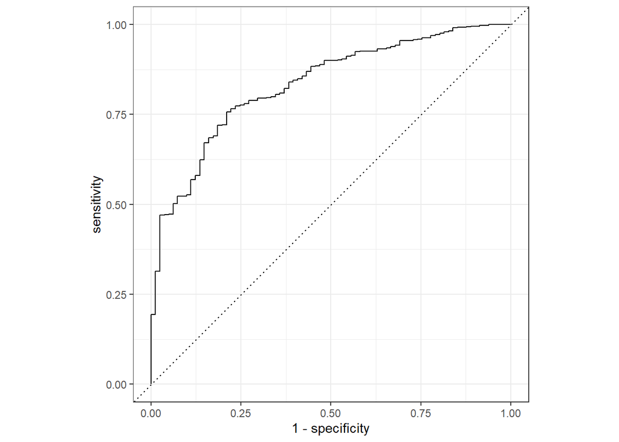

```r
# ROC curve for the final logistic regression model

roc_curve <- final_logistic_results %>%
  collect_predictions() %>%
  roc_curve(truth = Card_Penta1, .pred_0) %>%
  autoplot()
roc_curve
```

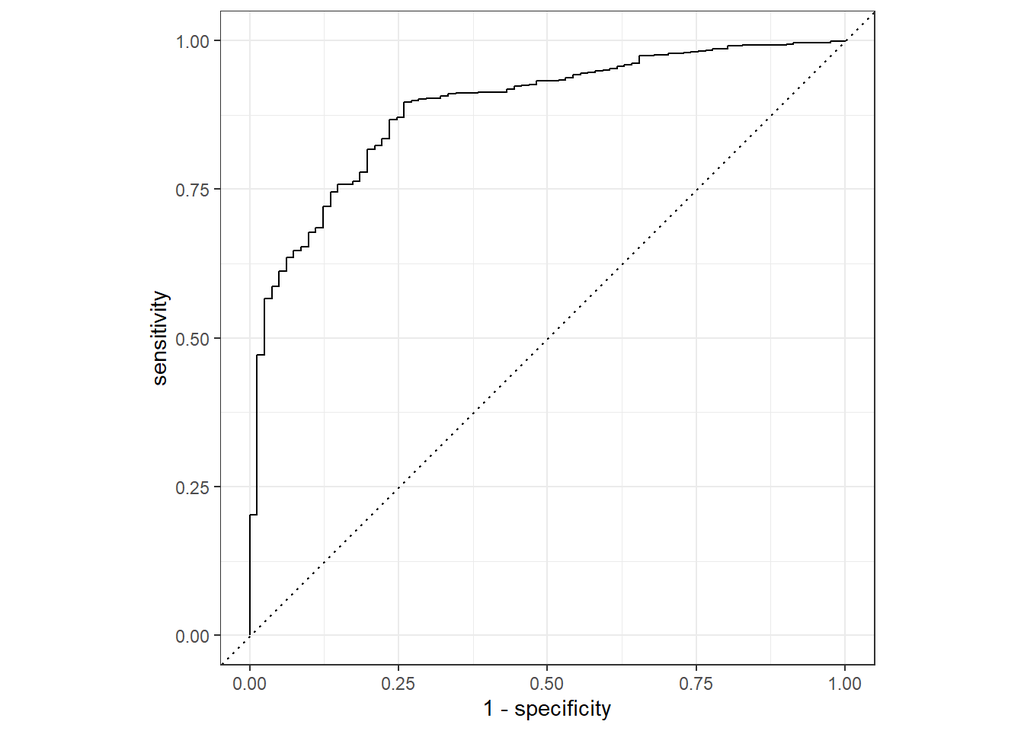

```r
# ROC curve for the final random forest model
roc_curve_rf <- final_rf_results %>%
  collect_predictions() %>%
  roc_curve(truth = Card_Penta1, .pred_0) %>%
  autoplot()
roc_curve_rf
```

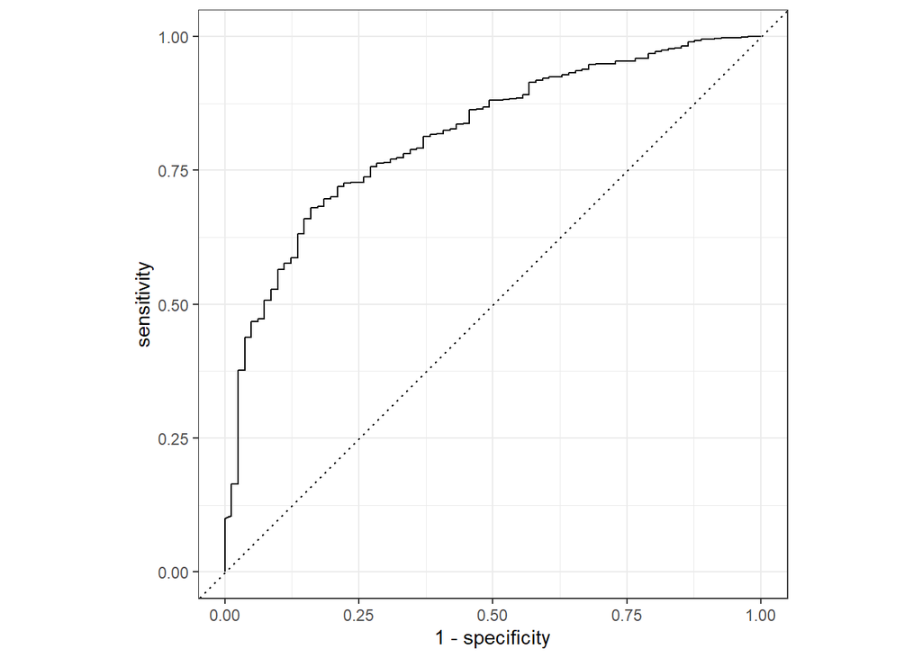

```r
# ROC curve for the final ANN model
roc_curve_mlp <- final_mlp_results %>%
  collect_predictions() %>%
  roc_curve(truth = Card_Penta1, .pred_0) %>%
  autoplot()
roc_curve_mlp
```

The above ROC curves indicate that the Random Forest model has the best performance in distinguishing between zero dose and non-zero dose children confirming that the Random Forest model is the best performing model among the three.

### Variable Importance

Based on the best performing model (Random Forest).

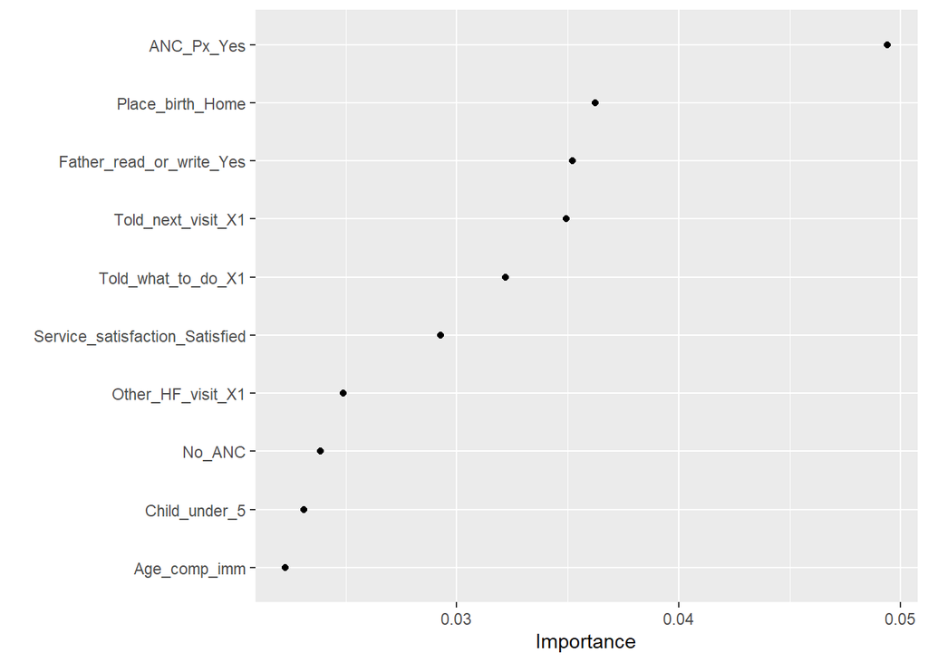

```r
prep <- prep(Card_Penta1_recipe)

rf_final_model %>%
  set_engine("ranger", importance = "permutation") %>%
  fit(Card_Penta1 ~ .,
    data = juice(prep)) %>%
  vip(geom = "point")
```

*Note:* I have used AI to understand the code and the concepts included in the assignment.